# Experiments 2 & 3: Demographics & Exclusions

Owen Morgan

October 18, 2024

**Summary**. We have recruited 366 right handers, and 1084 “left” and “mixed” handers. Of these, 357 right (98%), 685 left, and 288 mixed handers (90%) completed the experiment.

529 EHI left handers, 171 mixed handers, and 413 right handers meet inclusion criteria for Navon.

342 EHI left handers, 99 mixed handers, and 293 right handers meet inclusion criteria for both Navon and Dichotic listening.

## Recruitment & Exclusions

### Everyone

#### Exclusions: Any reason

| n (recruited) | n (with full task data) | exclusions | n (keepers) |
| --- | --- | --- | --- |
| 1,450 | 1,330 | 596 | 734 |

We have recruited 1450 participants through prolific. Of these, 1330 completed the task phase of the experiment.  
596 were excluded for the reasons described below, leaving 734 keepers.

How many subjects were excluded for multiple reasons?

| n_exclusion_reasons | n_subjects |
| --- | --- |
| 0 | 734 |
| 1 | 398 |
| 2 | 131 |
| 3 | 43 |
| 4 | 16 |
| 5 | 6 |
| 6 | 2 |

| n | Reason for exclusion |
| --- | --- |
| 410 | Dichotic listening: Failed headphone check (<5/6) |
| 139 | Prescreener/EHI mismatch |
| 115 | Dichotic listening: Failed stereo check (<5/6) |
| 78 | Dichotic listening: low mono accuracy (<75%) |
| 44 | Navon: Too many 'gos' (78/80 trials or more) |
| 39 | Dichotic listening: low dual accuracy (<60%) |
| 19 | Navon: Low accuracy (below 60% on any block) |
| 14 | Navon: Low RT (median < 200ms) |
| 12 | Reported having done the task before |
| 11 | Navon: High RT (median > 1500ms) |
| 5 | Quit before completing EHI |
| 4 | Age outside 18-40 |
| 4 | Non-US/UK country |
| 1 | Outlier based on visual inspection |

#### Exclusions: Navon

| n (recruited) | n (with full task data) | exclusions | n (keepers) |
| --- | --- | --- | --- |
| 1,450 | 1,330 | 217 | 1,113 |

217 were excluded for the reasons described below, leaving 1113 keepers.

How many subjects were excluded for multiple reasons?

| n_exclusion_reasons | n_subjects |
| --- | --- |
| 0 | 1,113 |
| 1 | 188 |
| 2 | 23 |
| 3 | 5 |
| 4 | 1 |

| n | Reason for exclusion |
| --- | --- |
| 139 | Prescreener/EHI mismatch |
| 44 | Navon: Too many 'gos' (78/80 trials or more) |
| 19 | Navon: Low accuracy (below 60% on any block) |
| 14 | Navon: Low RT (median < 200ms) |
| 12 | Reported having done the task before |
| 11 | Navon: High RT (median > 1500ms) |
| 5 | Quit before completing EHI |
| 4 | Age outside 18-40 |
| 4 | Non-US/UK country |
| 1 | Outlier based on visual inspection |

#### Exclusions: Dichotic Listening

| n (recruited) | n (with full task data) | exclusions | n (keepers) |
| --- | --- | --- | --- |
| 1,450 | 1,330 | 570 | 760 |

570 were excluded for the reasons described below, leaving 760 keepers.

How many subjects were excluded for multiple reasons?

| n_exclusion_reasons | n_subjects |
| --- | --- |
| 0 | 760 |
| 1 | 394 |
| 2 | 129 |
| 3 | 35 |
| 4 | 11 |
| 5 | 1 |

| n | Reason for exclusion |
| --- | --- |
| 410 | Dichotic listening: Failed headphone check (<5/6) |
| 139 | Prescreener/EHI mismatch |
| 115 | Dichotic listening: Failed stereo check (<5/6) |
| 78 | Dichotic listening: low mono accuracy (<75%) |
| 39 | Dichotic listening: low dual accuracy (<60%) |
| 12 | Reported having done the task before |
| 5 | Quit before completing EHI |
| 4 | Age outside 18-40 |
| 4 | Non-US/UK country |

Distribution of headphone check accuracy (which sound was the quietest?)

| headphonecheck_nCorrect | n |
| --- | --- |
| 6 | 752 |
| 5 | 168 |
| 0 | 155 |
| 4 | 79 |
| 1 | 67 |
| 2 | 63 |
| 3 | 46 |

Distribution of stereo check accuracy (did the sound play to the right or left ear?)

| stereocheck_nCorrect | n |
| --- | --- |
| 6 | 1,166 |
| 5 | 49 |
| 3 | 35 |
| 4 | 29 |
| 0 | 26 |
| 2 | 16 |
| 1 | 9 |

### By handedness group

All recruits before exclusions.

All recruits (before exclusions)

| handedness | N | Age (years) | Education (years) | Sex (M/F/O) | EHI |
| --- | --- | --- | --- | --- | --- |
| Left | 567 | 29.38 (5.71) | 14.88 (2.68) | 284/273/10 | -80.36 (19.44) |
| Mixed | 218 | 29.27 (6.25) | 14.71 (2.61) | 102/111/5 | 1.38 (25.53) |
| Right | 540 | 30.44 (5.8) | 14.61 (2.33) | 339/194/7 | 85.65 (17.56) |
| - | 5 | 28.5 (8.66) | 15 (2.58) | - | - |

Exclusions by Prolific handedness group

| prolific_handedness | n | Any exclusion | Navon | DL | EHI mismatch |
| --- | --- | --- | --- | --- | --- |
| Left | 685 | 321 | 113 | 312 | 79 |
| Mixed | 288 | 153 | 71 | 148 | 55 |
| Right | 357 | 122 | 33 | 110 | 5 |

Exclusions by EHI handedness group

| handedness | n | Any exclusion | Navon | DL | EHI mismatch |
| --- | --- | --- | --- | --- | --- |
| Left | 567 | 225 | 38 | 215 | 8 |
| Mixed | 218 | 119 | 47 | 117 | 36 |
| Right | 540 | 247 | 127 | 233 | 95 |
| - | 5 | 5 | 5 | 5 | 0 |

**Exclusions by Prolific handedness**

Right handers (n recruited = 357)

| n (Right) | Reason for exclusion |
| --- | --- |
| 122 | Any |
| 110 | dl |
| 81 | Failed headphone check (<5/6) |
| 33 | navon |
| 31 | Failed stereo check (<5/6) |
| 19 | Dichotic listening: low mono accuracy (<75%) |
| 15 | Navon: Too many 'gos' (78/80 trials or more) |
| 12 | Dichotic listening: low dual accuracy (<60%) |
| 9 | Navon: Low RT (median < 200ms) |
| 7 | Navon: Low accuracy (below 60% on any block) |
| 5 | Navon: High RT (median > 1500ms) |
| 5 | Prescreener/EHI mismatch |
| 2 | Non-US country |
| 2 | Reported having done the task before |
| 1 | Age outside 18-40 |
| 0 | Quit before completing EHI |
| 0 | visual |

Mixed handers (n recruited = 288)

| n (Mixed) | Reason for exclusion |
| --- | --- |
| 153 | Any |
| 148 | dl |
| 93 | Failed headphone check (<5/6) |
| 71 | navon |
| 55 | Prescreener/EHI mismatch |
| 28 | Dichotic listening: low mono accuracy (<75%) |
| 27 | Failed stereo check (<5/6) |
| 14 | Dichotic listening: low dual accuracy (<60%) |
| 10 | Navon: Too many 'gos' (78/80 trials or more) |
| 6 | Navon: Low accuracy (below 60% on any block) |
| 4 | Navon: High RT (median > 1500ms) |
| 3 | Navon: Low RT (median < 200ms) |
| 3 | Quit before completing EHI |
| 2 | Reported having done the task before |
| 1 | visual |
| 0 | Age outside 18-40 |
| 0 | Non-US country |

Left handers (n recruited = 685)

| n (Left) | Reason for exclusion |
| --- | --- |
| 321 | Any |
| 312 | dl |
| 236 | Failed headphone check (<5/6) |
| 113 | navon |
| 79 | Prescreener/EHI mismatch |
| 57 | Failed stereo check (<5/6) |
| 31 | Dichotic listening: low mono accuracy (<75%) |
| 19 | Navon: Too many 'gos' (78/80 trials or more) |
| 13 | Dichotic listening: low dual accuracy (<60%) |
| 8 | Reported having done the task before |
| 6 | Navon: Low accuracy (below 60% on any block) |
| 3 | Age outside 18-40 |
| 2 | Navon: High RT (median > 1500ms) |
| 2 | Navon: Low RT (median < 200ms) |
| 2 | Non-US country |
| 2 | Quit before completing EHI |
| 0 | visual |

**Exclusions by EHI handedness**

Right handers (n = 540)

| n (Right) | Reason for exclusion |
| --- | --- |
| 247 | Any |
| 233 | dl |
| 147 | Failed headphone check (<5/6) |
| 127 | navon |
| 95 | Prescreener/EHI mismatch |
| 46 | Failed stereo check (<5/6) |
| 38 | Dichotic listening: low mono accuracy (<75%) |
| 23 | Navon: Too many 'gos' (78/80 trials or more) |
| 21 | Dichotic listening: low dual accuracy (<60%) |
| 10 | Navon: Low RT (median < 200ms) |
| 9 | Navon: Low accuracy (below 60% on any block) |
| 6 | Navon: High RT (median > 1500ms) |
| 3 | Reported having done the task before |
| 2 | Age outside 18-40 |
| 2 | Non-US country |
| 0 | Quit before completing EHI |
| 0 | visual |

Mixed handers (n = 218)

| n (Mixed) | Reason for exclusion |
| --- | --- |
| 119 | Any |
| 117 | dl |
| 84 | Failed headphone check (<5/6) |
| 47 | navon |
| 36 | Prescreener/EHI mismatch |
| 25 | Failed stereo check (<5/6) |
| 16 | Dichotic listening: low mono accuracy (<75%) |
| 7 | Dichotic listening: low dual accuracy (<60%) |
| 7 | Navon: Too many 'gos' (78/80 trials or more) |
| 4 | Navon: Low RT (median < 200ms) |
| 3 | Navon: High RT (median > 1500ms) |
| 3 | Navon: Low accuracy (below 60% on any block) |
| 2 | Reported having done the task before |
| 1 | visual |
| 0 | Age outside 18-40 |
| 0 | Non-US country |
| 0 | Quit before completing EHI |

Left handers (n = 567)

| n (Left) | Reason for exclusion |
| --- | --- |
| 225 | Any |
| 215 | dl |
| 178 | Failed headphone check (<5/6) |
| 43 | Failed stereo check (<5/6) |
| 38 | navon |
| 24 | Dichotic listening: low mono accuracy (<75%) |
| 14 | Navon: Too many 'gos' (78/80 trials or more) |
| 11 | Dichotic listening: low dual accuracy (<60%) |
| 8 | Prescreener/EHI mismatch |
| 7 | Navon: Low accuracy (below 60% on any block) |
| 7 | Reported having done the task before |
| 2 | Navon: High RT (median > 1500ms) |
| 1 | Age outside 18-40 |
| 1 | Non-US country |
| 0 | Navon: Low RT (median < 200ms) |
| 0 | Quit before completing EHI |
| 0 | visual |

## Demographics (Keepers)

### Navon + DL

Demographics for included participants, by handedness group (EHI bins).

| Handedness | N | Age (years) | Education (years) | Sex (M/F/O) | EHI |
| --- | --- | --- | --- | --- | --- |
| Left | 342 | 29.25 (5.7) | 14.9 (2.68) | 183/153/6 | -80.04 (19.25) |
| Mixed | 99 | 28.6 (6) | 14.72 (2.35) | 45/51/3 | -0.51 (28.06) |
| Right | 293 | 30.53 (5.85) | 14.33 (2.31) | 188/101/4 | 84.81 (17.3) |

Left: (EHI <= -40) | Mixed: (-40 < EHI < 40) | Right: (EHI >= 40)

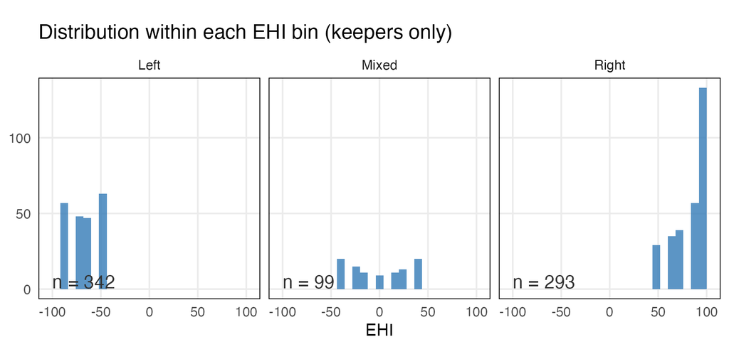

Demographics for all included participants.

Demographics

Summary

| N | Age (years) | Education (years) | Sex (M/F/O) | EHI |
| --- | --- | --- | --- | --- |
| 734 | 29.67 (5.84) | 14.65 (2.5) | 416/305/13 | -3.51 (79.05) |

| Country | n |
| --- | --- |
| US | 422 |
| UK | 312 |

| Race | n |
| --- | --- |
| White | 557 |
| Multiple | 63 |
| Asian | 54 |
| Black or African American | 53 |
| American Indian or Alaska Native | 6 |
| Other | 1 |

| Hispanic ethnicity | n |
| --- | --- |
| No | 666 |
| Yes | 68 |

### Navon

Demographics for included participants, by handedness group (EHI bins).

| Handedness | N | Age (years) | Education (years) | Sex (M/F/O) | EHI |
| --- | --- | --- | --- | --- | --- |
| Left | 529 | 29.2 (5.7) | 14.94 (2.69) | 263/257/9 | -80.2 (19.39) |
| Mixed | 171 | 28.64 (6.11) | 14.78 (2.43) | 70/97/4 | -0.66 (27.16) |
| Right | 413 | 30.57 (5.81) | 14.48 (2.35) | 262/146/5 | 83.81 (17.72) |

Left: (EHI <= -40) | Mixed: (-40 < EHI < 40) | Right: (EHI >= 40)

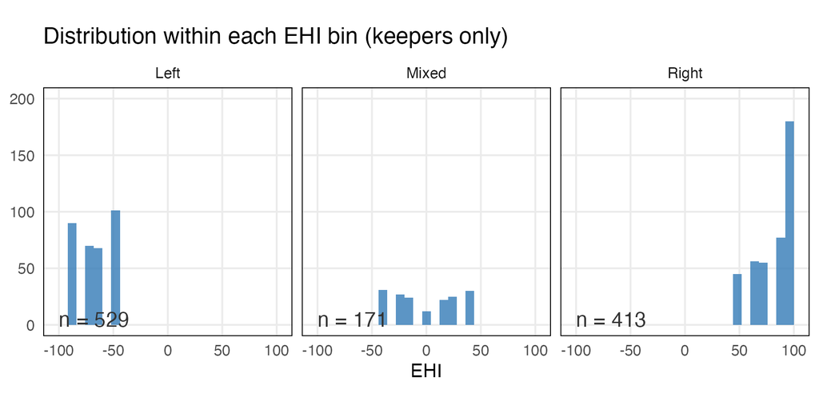

Demographics for all included participants.

Demographics

Summary

| N | Age (years) | Education (years) | Sex (M/F/O) | EHI |
| --- | --- | --- | --- | --- |
| 1,113 | 29.62 (5.85) | 14.74 (2.54) | 595/500/18 | -7.12 (77.62) |

| Country | n |
| --- | --- |
| US | 615 |
| UK | 498 |

| Race | n |
| --- | --- |
| White | 831 |
| Black or African American | 96 |
| Multiple | 90 |
| Asian | 84 |
| American Indian or Alaska Native | 7 |
| Native Hawaiian or Other Pacific Islander | 3 |
| Other | 2 |

| Hispanic ethnicity | n |
| --- | --- |
| No | 1,014 |
| Yes | 99 |

### Dichotic Listening

Demographics for included participants, by handedness group (EHI bins).

| Handedness | N | Age (years) | Education (years) | Sex (M/F/O) | EHI |
| --- | --- | --- | --- | --- | --- |
| Left | 352 | 29.27 (5.7) | 14.89 (2.67) | 188/158/6 | -80.01 (19.34) |
| Mixed | 101 | 28.62 (5.99) | 14.71 (2.34) | 47/51/3 | -0.12 (27.92) |
| Right | 307 | 30.58 (5.85) | 14.34 (2.3) | 196/107/4 | 85.02 (17.13) |

Left: (EHI <= -40) | Mixed: (-40 < EHI < 40) | Right: (EHI >= 40)

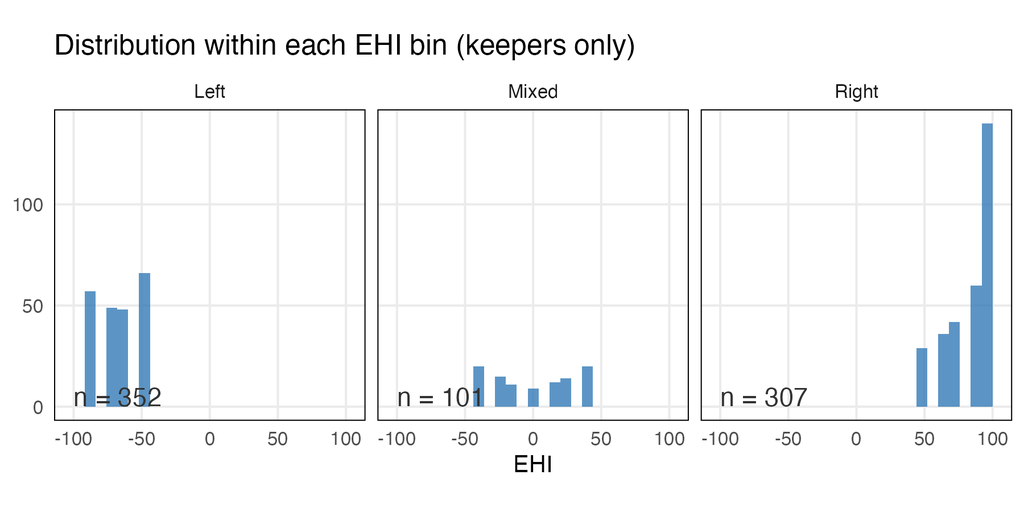

Demographics

Summary

| N | Age (years) | Education (years) | Sex (M/F/O) | EHI |
| --- | --- | --- | --- | --- |
| 760 | 29.71 (5.84) | 14.64 (2.49) | 431/316/13 | -2.73 (79.24) |

| Country | n |
| --- | --- |
| US | 441 |
| UK | 319 |

| Race | n |
| --- | --- |
| White | 576 |
| Multiple | 65 |
| Asian | 56 |
| Black or African American | 56 |
| American Indian or Alaska Native | 6 |
| Other | 1 |

| Hispanic ethnicity | n |
| --- | --- |
| No | 687 |
| Yes | 73 |

### Group differences?

Any demographics differences between handedness groups?

#### Navon (Exp 2)

Age (years)

| contrast | estimate | SE | df | lower.CL | upper.CL | t.ratio | p.value |
| --- | --- | --- | --- | --- | --- | --- | --- |
| Left - Right | −1.369 | 0.377 | 940 | −2.11 | −0.628 | −3.627 | 3e-04 |

Education (years)

| contrast | estimate | SE | df | lower.CL | upper.CL | t.ratio | p.value |
| --- | --- | --- | --- | --- | --- | --- | --- |
| Left - Right | 0.457 | 0.168 | 936 | 0.127 | 0.786 | 2.722 | .007 |

Sex

| contrast | odds.ratio<sup>1</sup> | SE | df | asymp.LCL | asymp.UCL | null | z.ratio | p.value |
| --- | --- | --- | --- | --- | --- | --- | --- | --- |
| Left / Right | 0.57 | 0.077 | Inf | 0.437 | 0.744 | 1 | −4.145 | <.0001 |

#### Navon + Dichotic (Exp 3)

Age (years)

| contrast | estimate | SE | df | lower.CL | upper.CL | t.ratio | p.value |
| --- | --- | --- | --- | --- | --- | --- | --- |
| Left - Right | −1.278 | 0.459 | 633 | −2.179 | −0.376 | −2.783 | 0.006 |

Education (years)

| contrast | estimate | SE | df | lower.CL | upper.CL | t.ratio | p.value |
| --- | --- | --- | --- | --- | --- | --- | --- |
| Left - Right | 0.565 | 0.201 | 630 | 0.171 | 0.959 | 2.816 | 0.005 |

Sex

| contrast | odds.ratio<sup>1</sup> | SE | df | asymp.LCL | asymp.UCL | null | z.ratio | p.value |
| --- | --- | --- | --- | --- | --- | --- | --- | --- |
| Left / Right | 0.643 | 0.106 | Inf | 0.465 | 0.888 | 1 | −2.681 | 0.007 |